# RQGIS: Integrating R with QGIS for Statistical Geocomputing

## 3 Ecological example: combining geocomputing and statistics

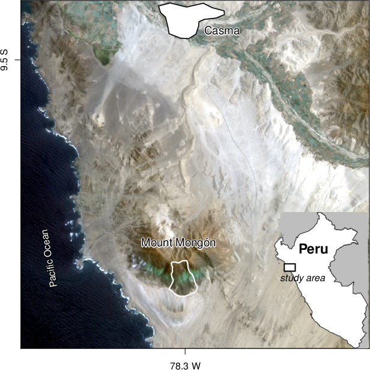

Figure 3: The study area Mount Mongón in northern Peru (Landsat image: path 9, row 67, acquisition date 09/22/2000; USGS 2016).

To show the utility of *RQGIS* in real-world applications, we combine QGIS functionality with R’s modeling and (geo-)statistical capabilities in an ecological study in the coastal desert of northern Peru (Figure 3). Despite the extreme aridity of the Mount Mongón region (200-1100 m asl), this area is the habitat of a distinct flora and fauna (Dillon et al. 2003). The unique vegetation, locally termed *lomas*, mainly survives due to heavy fog during the austral winter months (Muenchow et al. 2013b,c).

Linking species richness to environmental predictors along gradients is a key topic of community ecology and biogeography (Muenchow et al. 2017), and the fundamental basis for conservation planning (Pomara et al. 2012). In our use case, we model vascular plant species richness along an altitudinal gradient as a function of topographic and remotely sensed variables by means of count regression. In the following, we will show a simplified version of an analysis by Muenchow et al. (2013b).

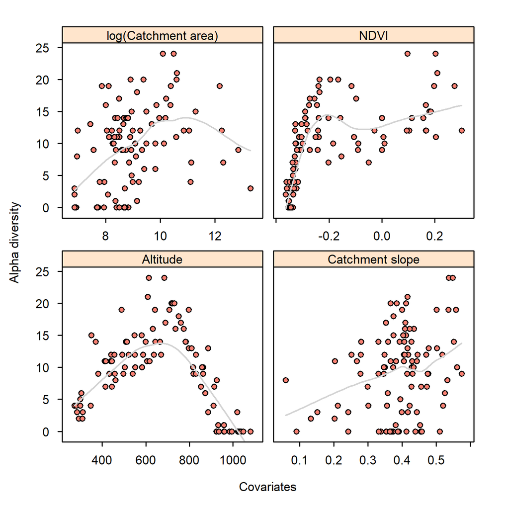

Figure 4: Scatterplot of all predictors used in the Poisson model against the response variable. Each dot represents a visited plot on Mount Mongón. The gray line smoother should aid visual inspection.

### 3.1 Terrain attributes

The numerical representation as well as the analysis of the land surface is frequently referred to as terrain analysis and terrain modeling. The corresponding surface-characterizing measures are known as terrain attributes (Pike et al. 2008). Terrain attributes play an important role, for example, in pedometrics (McBratney et al. 2000), precision agriculture (Kühn et al. 2009), geomorphometry (Pike et al. 2008) and ecology (Muenchow et al. 2013a). They are frequently related to slope stability (Montgomery and Dietrich 1994; Muenchow et al. 2012). Additionally, they are proxies for variables representing water availability such as soil moisture, soil texture or moisture-holding capacity, among others (Franklin et al. 2000; Brenning 2008; Muenchow et al. 2013c). Especially the latter is of utmost importance regarding plant distribution in a desert environment. While GIS can easily calculate terrain attributes, R is rather limited in this respect. However, without terrain attributes, we would neither be able to model nor predict species richness appropriately.

First we would like to use SAGA to remove local depressions from the DEM, since these may be artifacts. For this, we use the `[1] Fill Sinks` method. Note that you also may use numbers for specifying the option, here, the fill sinks method corresponds to 1.

```r
get_usage("saga:sinkremoval")
## ALGORITHM: Sink removal
##  DEM <ParameterRaster>
##  SINKROUTE <ParameterRaster>
##  METHOD <ParameterSelection>
##  THRESHOLD         <ParameterBoolean>
##  THRSHEIGHT <ParameterNumber>
##  _RESAMPLING <ParameterSelection>
##  DEM_PREPROC <OutputRaster>
##
##
## METHOD(Method)
##  0 - [0] Deepen Drainage Routes
##  1 - [1] Fill Sinks
## _RESAMPLING(Resampling method)
##  0 - Nearest Neighbour
##  1 - Bilinear Interpolation
##  2 - Bicubic Spline Interpolation
##  3 - B-Spline Interpolation
run_qgis(alg = "saga:sinkremoval",
         DEM = dem,
         METHOD = "[1] Fill Sinks",
         DEM_PREPROC = file.path(tempdir(), "sdem.sdat"),
         show_output_paths = FALSE)
```

Next, we compute the catchment area (or upslope contributing area) and its mean slope from the preprocessed DEM. These raster datasets are calculated while calculating the ‘Saga wetness index’, which is also frequently used as a predictor in ecological studies. To calculate the catchment slope instead of the local slope we set the `SLOPE_TYPE` argument to 1. The names of the output rasters are `carea.sdat` and `cslope.sdat` both of which will be stored in `tempdir()`.

```r
get_usage("saga:sagawetnessindex")
## ALGORITHM: Saga wetness index
##  DEM <ParameterRaster>
##  SUCTION <ParameterNumber>
##  AREA_TYPE <ParameterSelection>
##  SLOPE_TYPE <ParameterSelection>
##  SLOPE_MIN <ParameterNumber>
##  SLOPE_OFF <ParameterNumber>
##  SLOPE_WEIGHT <ParameterNumber>
##  _RESAMPLING <ParameterSelection>
##  AREA <OutputRaster>
##  SLOPE <OutputRaster>
##  AREA_MOD <OutputRaster>
##  TWI <OutputRaster>
##
##
## AREA_TYPE(Type of Area)
##  0 - [0] absolute catchment area
##  1 - [1] square root of catchment area
##  2 - [2] specific catchment area
## SLOPE_TYPE(Type of Slope)
##  0 - [0] local slope
##  1 - [1] catchment slope
## _RESAMPLING(Resampling method)
##  0 - Nearest Neighbour
##  1 - Bilinear Interpolation
##  2 - Bicubic Spline Interpolation
##  3 - B-Spline Interpolation
run_qgis(alg = "saga:sagawetnessindex",
         DEM = file.path(tempdir(), "sdem.sdat"),
         SLOPE_TYPE = 1,
         SLOPE = file.path(tempdir(), "cslope.sdat"),
         AREA = file.path(tempdir(), "carea.sdat"),
         show_output_paths = FALSE)
```

To have a look at the output rasters, we can run (not shown):

```r
library("dplyr")
library("raster")
file.path(tempdir(), c("cslope.sdat", "carea.sdat")) %>%
  raster::stack(.) %>%
  plot
```

We furthermore need to apply some transformations to these raster files for improved interpretability. On the one hand, we convert slope angle from radians to degrees.

```r
library("raster")
cslope <- raster(file.path(tempdir(), "cslope.sdat"))
cslope <- cslope * 180 /pi
```

On the other hand, we divide the catchment area variable by one million to change the unit from m<sup>2</sup> to km<sup>2</sup>. Furthermore, we transform it logarithmically since it is strongly skewed to the right.

```r
carea <- raster(file.path(tempdir(), "carea.sdat"))
log_carea <- log(carea / 1e+06)
```

Apart from the catchment area and catchment slope, our final model requires the NDVI as an indicator of vegetation properties. To calculate it, we would have to perform pixel-by-pixel arithmetic operations on raster data sets representing the Landsat satellite’s spectral bands three (red) and four (near infrared). These so-called map algebra operations are available through *raster* and the QGIS modules `saga:rastercalculator` and `grass:r.mapcalculator`; however, the *RQGIS* package already provides the NDVI raster as an example dataset. Therefore, we merely have to attach the data to our workspace.

```r
data("ndvi", package = "RQGIS")
```

To account for the nonlinear unimodal relationship between elevation and species richness, we need two rasters representing the second-order orthogonal polynomials of the original DEM. First, we convert the elevation unit from m to km by dividing the original DEM raster by 1000. Next, we use R’s built-in `poly()` function to calculate the orthogonal polynomials for each pixel in our DEM raster to avoid collinearity among the predictors. Before saving the resulting rasters and the catchment slope, the catchment area and the NDVI to a temporary output location, we apply the `crop()` function from the *raster* package to ensure that all rasters share the same extent.

```r
data("dem", package = "RQGIS")
dem <- dem / 1000
my_poly <- poly(values(dem), degree = 2)
dem1 <- dem2 <- dem
values(dem1) <- my_poly[, 1]
values(dem2) <- my_poly[, 2]
for (i in c("dem1", "dem2", "log_carea", "cslope", "ndvi")) {
  tmp <- crop(get(i), dem)
  writeRaster(x = tmp,
              filename = file.path(tempdir(), paste0(i, ".asc")),
              format = "ascii",
              prj = TRUE,
              overwrite = TRUE)
}
```

After creating these raster datasets, we would like to extract their attributes to the randomly sampled points. Conveniently, RSAGA’s `pick.from.ascii.grids()` function accepts multiple rasters for parallel attribute extraction. Note that `pick.from.ascii.grids()` is a pure R function, i.e., it runs without accessing SAGA. Here, we only extract the predictor variables needed in the final model (see above). The `"sf"` object `random_points` refers to randomly sampled points we visited in the field. Unfortunately, `pick.from.ascii.grids()` does not accept spatial point objects as input; instead we have to provide it with a `"data.frame"` and indicate which columns refer to the coordinates. In the `file` argument we specify the raster files from which we would like to extract values to our points. The output columns in `vals` will be named like the input rasters.

```r
library("dplyr")
data("random_points", package = "RQGIS")
random_points[, c("x", "y")] <- sf::st_coordinates(random_points)
raster_names <- c("dem1", "dem2", "log_carea", "cslope", "ndvi")
vals <- RSAGA::pick.from.ascii.grids(data = as.data.frame(random_points),
                                     X.name = "x",
                                     Y.name = "y",
                                     file = file.path(tempdir(), raster_names),
                                     varname = raster_names)
dplyr::select(vals, -geometry) %>%
  head(., 3)
```

```
##   id spri      x       y     dem1    dem2 log_carea cslope    ndvi
## 1  1    4 797179 8932755 -0.01049 0.01268  -1.21800  21.18 -0.3603
## 2  2    4 796749 8932621 -0.01019 0.01163   0.04145  13.02 -0.3488
## 3  3    3 796816 8932739 -0.01008 0.01124  -0.48148  23.70 -0.3396
```